# 6. Builders’ Guide

Dive-into-Deep-Learning

A deep dive into the key components of deep learning computation, namely model building, parameter access and initialization, designing custom layers and blocks, reading and writing models to disk, and achieving significant acceleration with GPUs

Author

Wu Hao

Published

2025/2/7

# Layers and Modules

We can regard a module as a single layer, a component consisting of multiple layers, to implement a complex network.

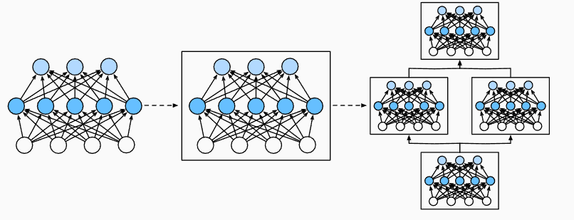

Multiple layers are combined into modules, forming repeating patterns of larger models

```python
import torch
from torch import nn
from torch.nn import functional as F
from d2l import torch as d2l
```

Refers to the MLPs concise implement, we generates a network with one fully connected hidden layer with 256 units and ReLU activation, followed by a fully connected layer with ten units.

```python
net = nn.Sequential(nn.LazyLinear(256), nn.ReLU(), nn.LazyLinear(10))

X = torch.rand(2, 20)
net(X).shape
```

```
torch.Size([2, 10])
```

## A Custom Module

The basic functionality that each module must provide:

1. Ingest input data as arguments to its forward propagation method.
2. Generate an output by having the forward propagation method return a value. Note that the output may have a different shape from the input. For example, the first fully connected layer in our model above ingests an input of arbitrary dimension but returns an output of dimension 256.
3. Calculate the gradient of its output with respect to its input, which can be accessed via its backpropagation method. Typically this happens automatically.
4. Store and provide access to those parameters necessary for executing the forward propagation computation.
5. Initialize model parameters as needed.

```python
class MLP(nn.Module):
    def __init__(self):
        super().__init__()
        self.hidden = nn.LazyLinear(256) # [num, A] --> [num, 256]
        self.out = nn.LazyLinear(10)  # output: 10 dims

    def forward(self, X):
        print(f"Shape of hidden layers is {self.hidden(X).shape}")
        return self.out(F.relu(self.hidden(X)))

print(f"Shape of input is {X.shape}")
net = MLP()
net(X).shape
```

```
Shape of input is torch.Size([2, 20])
Shape of hidden layers is torch.Size([2, 256])
```

```
torch.Size([2, 10])
```

## The Sequential Module

Recall that `Sequential` was designed to daisy-chain other modules together.

```python
class MySequential(nn.Module):
    def __init__(self, *args):
        super().__init__()
        for idx, module in enumerate(args):
            self.add_module(str(idx), module)

    def forward(self, X):
        for module in self.children():
            X = module(X)
        return X

net = MySequential(nn.LazyLinear(256), nn.ReLU(), nn.LazyLinear(10))
net(X).shape
```

```
torch.Size([2, 10])
```

## Executing Code in the Forward Propagation Method

Sometimes we want to incorporate terms that are neither the result of previous layers nor updatable parameters. We call these constant parameters. So we implement a `FixedHiddenMLP` class as follows.

```python
class FixedHiddenMLP(nn.Module):
    def __init__(self):
        super().__init__()
        self.rand_weight = torch.rand((20, 20))
        self.linear = nn.LazyLinear(20)

    def forward(self, X):
        X = self.linear(X)
        X = F.relu(torch.mm(X, self.rand_weight)+1)
        X = self.linear(X)

        while X.abs().sum() >1:
            X/=2
        return X.sum()
```

`self.rand_weight` is initialized randomly at instantiation and are thereafter constant. This weight is not a model parameter and thus it is never updated by backpropagation. The network then passes the output of this “fixed” layer through a fully connected layer.

```python
net = FixedHiddenMLP()
net(X)
```

```
tensor(-0.0171, grad_fn=<SumBackward0>)
```

We can mix and match various ways of assembling modules together.

```python
class NestMLP(nn.Module):
    def __init__(self):
        super().__init__()
        self.net = nn.Sequential(nn.LazyLinear(64), nn.ReLU(),
                                nn.LazyLinear(32), nn.ReLU())
        self.linear = nn.LazyLinear(16)

    def forward(self, X):
        return self.linear(self.net(X))

# FixedHiddenMLP input: [num, 20]
chimera = nn.Sequential(NestMLP(), nn.LazyLinear(20), FixedHiddenMLP())
chimera(X)
```

```
tensor(0.0285, grad_fn=<SumBackward0>)
```

# Parameter Management

## Parameter Access

When a model is defined via the `Sequential` class, we can first access any layer by indexing into the model as though it were a list.

```python
# nn.LazyLinear(20)
chimera[1].state_dict()
```

[output not shown]

[output cut: 30 more lines]

```
                        1.6572e-01,  1.8262e-01,  1.2705e-01,  1.7699e-01, -2.0911e-01,
                        2.0755e-01,  1.9284e-01, -2.2792e-01, -1.4515e-01,  1.8955e-01,
                        6.7077e-02],
                      [ 2.5097e-02,  1.2460e-01, -2.2954e-01, -5.1462e-02,  1.9205e-01,
                       -1.9997e-01,  1.2961e-01,  2.0938e-02,  2.2178e-01, -2.2595e-01,
                        1.8142e-01, -1.2669e-01, -4.7391e-02,  2.4234e-01, -2.1872e-01,
                       -5.3722e-02],
                      [ 2.3587e-01, -1.8849e-01, -1.4434e-01,  1.2101e-01, -2.3800e-02,
                       -1.0924e-01, -1.3102e-01,  2.3507e-01,  1.5755e-01, -1.6030e-02,
                       -1.4918e-01, -2.0011e-01,  1.2580e-01,  2.0837e-01, -1.5118e-01,
                       -2.1362e-01]])),
             ('bias',
              tensor([ 0.0759, -0.1066, -0.0574, -0.2373, -0.1198,  0.0214, -0.2121, -0.0601,
                      -0.1591, -0.0459, -0.1004, -0.1534, -0.1526, -0.1216,  0.1801, -0.1995,
                       0.0456, -0.0667,  0.2441, -0.0088]))])
```

### targeted Parameters

```python
# nn.LazyLinear(20)
type(chimera[1].bias), chimera[1].bias.data
chimera[1].weight.grad == None
```

```
True
```

## Tied Parameters

We often share parameters across multiple layers. In the following, we allocate a fully connected layer and then use its parameters specifically to set those of another layer.

```python
shared = nn.LazyLinear(8)
net = nn.Sequential(nn.LazyLinear(8), nn.ReLU(),
                    shared, nn.ReLU(),
                    shared, nn.ReLU(),
                    nn.LazyLinear(1))
print(f"the structure of net is\n {net}")
net(X)
print(net[2].weight.data[0] == net[4].weight.data[0])
net[2].weight.data[0, 0] = 100
print(net[2].weight.data[0] == net[4].weight.data[0])
```

```
the structure of net is
 Sequential(
  (0): LazyLinear(in_features=0, out_features=8, bias=True)
  (1): ReLU()
  (2): LazyLinear(in_features=0, out_features=8, bias=True)
  (3): ReLU()
  (4): LazyLinear(in_features=0, out_features=8, bias=True)
  (5): ReLU()
  (6): LazyLinear(in_features=0, out_features=1, bias=True)
)
tensor([True, True, True, True, True, True, True, True])
tensor([True, True, True, True, True, True, True, True])
```

# Parameter Initialization.

The deep learning framework provides default random initializations to its layers. However, we often want to initialize our weights according to various other protocols. The framework provides most commonly used protocols, and also allows to create a custom initializer.

## Built-in Initialization

The code below initializes all weight parameter as Gaussian random variables with standard deviation 0.01, while bias parameters are cleared to zero.

```python
def init_normal_1(module):
    if type(module) == nn.Linear:
        nn.init.normal_(module.weight, mean=0, std=0.01)
        nn.init.zeros_(module.bias)

net.apply(init_normal_1)
net[0].weight.data[0], net[0].bias.data[0]
```

```
(tensor([ 0.0045,  0.0065,  0.0138, -0.0172, -0.0082,  0.0138, -0.0179, -0.0001,
          0.0011, -0.0115,  0.0071,  0.0205, -0.0069, -0.0007,  0.0144, -0.0020,
          0.0131, -0.0023, -0.0008,  0.0240]),
 tensor(0.))
```

```python
def init_normal_2(module):
    if type(module) == nn.Linear:
        nn.init.normal_(module.weight, 1)
        nn.init.zeros_(module.bias)

net.apply(init_normal_2)
net[0].weight.data[0], net[0].bias.data[0]
```

```
(tensor([ 0.2364,  0.7411,  1.5362,  3.5715,  2.0515,  1.4491, -0.3065,  0.4393,
          1.1090,  0.5221,  0.2897, -0.3381,  1.9912,  0.7248, -0.1787,  0.1563,
          0.9460,  1.7286,  2.3895,  0.8993]),
 tensor(0.))
```

We can also apply different initializers for certain blocks.

```python
def init_xavier(module):
    if type(module) == nn.Linear:
        nn.init.xavier_uniform_(module.weight)

def init_42(module):
    if type(module) == nn.Linear:
        nn.init.constant_(module.weight, 42)

net[0].apply(init_xavier)
net[2].apply(init_42)
print(net[0].weight.data[0])
print(net[2].weight.data)
```

```
tensor([-0.1111, -0.2314,  0.0279,  0.3737,  0.4304,  0.4095,  0.2606, -0.4418,
        -0.1398, -0.4494,  0.2470, -0.1376,  0.1707,  0.0035,  0.0220, -0.4032,
         0.2351, -0.3310,  0.1457,  0.4154])
tensor([[42., 42., 42., 42., 42., 42., 42., 42.],
        [42., 42., 42., 42., 42., 42., 42., 42.],
        [42., 42., 42., 42., 42., 42., 42., 42.],
        [42., 42., 42., 42., 42., 42., 42., 42.],
        [42., 42., 42., 42., 42., 42., 42., 42.],
        [42., 42., 42., 42., 42., 42., 42., 42.],
        [42., 42., 42., 42., 42., 42., 42., 42.],
        [42., 42., 42., 42., 42., 42., 42., 42.]])
```

## Lazy Initialization

So far, it might seem that we got away with being sloppy in setting up our networks Specifically, we did the following unintuitive things, which might not seem like they should work:

1. We defined the network architectures without specifying the input dimensionality.
2. We added layers without specifying the output dimension of the previous layer.
3. We even “initialized” these parameters before providing enough information to determine how many parameters our models should contain.

We introduce the *defers initialization* in here, which can wait until the first time we pass data through the model, to infer the sizes of each layer on the fly.

To begin, let’s initialize an MLP.

```python
net = nn.Sequential(nn.LazyLinear(256), nn.ReLU(), nn.LazyLinear(10))
```

Since the input dimension remains unknown, the network cannot possibly know the dimensions of the input layer’s weights.

The framework has not yet initialized any parameters. We confirm by attempting to access the parameters below.

```python
net[0].weight
```

```
<UninitializedParameter>
```

Next let’s pass data through the network to make the framework finally initialize parameters.

```python
X = torch.rand(2, 20)
net(X)

net[0].weight.shape
```

```
torch.Size([256, 20])
```

# Custom Layers

One factor behind deep learning’s success is the availability of a wide range of layers that can be composed in creative ways to design architectures suitable for a wide variety of tasks.

## Layers without Parameters

To start, we construct a custom layer that does not have any parameters of its own and feed some data through it.

```python
class CenteredLayer(nn.Module):
    def __init__(self):
        super().__init__()

    def forward(self, X):
        return X - X.mean()

layer = CenteredLayer()
layer(torch.tensor([1.0, 2, 3, 4, 5]))
```

```
tensor([-2., -1.,  0.,  1.,  2.])
```

Next, we can incorporate our layers as a component in constructing more complex models.

```python
net = nn.Sequential(nn.LazyLinear(128), CenteredLayer())
```

As an extra sanity check, we can send random data through the network and check that the mean is in fact 0.

```python
Y = net(torch.rand(4, 8))
Y.mean()
```

```
tensor(7.4506e-09, grad_fn=<MeanBackward0>)
```

Because we are dealing with floating point numbers, we may still see a very small nonzero number due to quantization.

## Layers with Parameters

Now let’s implement our own version of the fully connected layer. Recall that this layer requires two parameters, one to represent the weight and the other for the bias.

```python
class MyLinear(nn.Module):
    def __init__(self, in_dim, out_dim):
        super().__init__()
        self.weight = nn.Parameter(torch.randn(in_dim, out_dim))
        self.bias = nn.Parameter(torch.randn(out_dim,))
    def forward(self, X):
        linear = torch.matmul(X, self.weight.data) + self.bias.data
        return F.relu(linear)

model = MyLinear(5, 3)
model.weight
```

```
Parameter containing:
tensor([[ 0.7735,  1.0140,  0.4311],
        [ 0.7936, -0.3091, -1.4900],
        [-0.3873,  1.6363, -0.8566],
        [-0.0753,  0.4917, -0.5802],
        [ 1.0748,  0.7232,  0.4453]], requires_grad=True)
```

We can directly carry out forward propagation calculations using custom layers.

```python
model(torch.rand(2, 5))
```

```
tensor([[0.3792, 0.0000, 0.0000],
        [1.3929, 1.3724, 0.2937]])
```

We can also construct models using custom layers. Once we have that we can use it just like the built-in fully connected layer.

```python
model = nn.Sequential(MyLinear(64, 8), MyLinear(8, 1))
model(torch.rand(2, 64))
```

```
tensor([[0.],
        [0.]])
```

# File I/O

## Loading and Saving Tensors

We can directly invoke the `load` and `save` functions to read and write them respectively. Both functions require that we supply a name, and `save` requires as input the variable to be saved.

```python
x = torch.arange(4)
torch.save(x, 'x-file')

#read data
x2 = torch.load('x-file', weights_only=True)
x2
```

```
tensor([0, 1, 2, 3])
```

We can store a list of tensors and then read them back into memory.

```python
y = torch.zeros(4)
torch.save([x, y],'x-files')
x2, y2 = torch.load('x-files')
(x2, y2)
```

```
(tensor([0, 1, 2, 3]), tensor([0., 0., 0., 0.]))
```

We can even write and read a dictionary that maps from strings to tensors. This is convenient when we want to read or write all the weights in a model.

```python
mydict = {'x': x, 'y': y}
torch.save(mydict, 'mydict')
mydict2 = torch.load('mydict', weights_only=True)
mydict2
```

```
{'x': tensor([0, 1, 2, 3]), 'y': tensor([0., 0., 0., 0.])}
```

## Loading and Saving Model Parameters

The deep learning framework provides built-in functionalities to load and save entire networks. Let’s start with our familiar MLP.

```python
class MLP(nn.Module):
    def __init__(self):
        super().__init__()
        self.hidden = nn.LazyLinear(256)
        self.output = nn.LazyLinear(10)
    def forward(self, X):
        return self.output(F.relu(self.hidden(X)))

net = MLP()
X = torch.randn(size= (2,20))
Y= net(X)
```

Next, we store the parameters of the model as a file with the name “mlp.params”.

```python
torch.save(net.state_dict(), './data/mlp.params')
```

To recover the model, we instantiate a clone of the original MLP model. Instead of randomly initializing the model parameters, we read the parameters stored in the file directly.

```python
clone = MLP()
clone.load_state_dict(torch.load('./data/mlp.params', weights_only=True))
clone.eval()
```

```
MLP(
  (hidden): LazyLinear(in_features=0, out_features=256, bias=True)
  (output): LazyLinear(in_features=0, out_features=10, bias=True)
)
```

# GPUs

We begin to discuss how to harness the GPUs for our research. First by using a single GPU and at a later point, how to use multiple GPUs and multiple servers (with multiple GPUs).

## Computing Devices

We can specify devices, such as CPUs and GPUs, for storage and calculation. By default, tensors are created in the main memory and then the CPU is used for calculations.

In PyTorch, the CPU and GPU can be indicated by `torch.device('cpu')` and `torch.device('cuda')`. If there are multiple GPUs, we use `torch.device(f'cuda:{i}')` to represent the $i^{th}$ GPU ($i$ starts at 0). Also, `gpu:0` and `gpu` are equivalent.

```python
def cpu():
    return torch.device('cpu')

def gpu(i=0):
    return torch.device(f'cuda:{i}')

cpu(), gpu(), gpu(1)
```

```
(device(type='cpu'),
 device(type='cuda', index=0),
 device(type='cuda', index=1))
```

We can query the number of available GPUs.

```python
def num_gpus():
    return torch.cuda.device_count()

num_gpus()
```

```
1
```

Now we define two convenient functions that allow us to run code even if the requested GPUs do not exist.

```python
def try_gpu(i=0):
    """Return gpu(i) if exists, otherwise return cpu()."""
    if num_gpus() >= i + 1:
        return gpu(i)
    return cpu()

def try_all_gpus():
    """Return all available GPUs, or [cpu(),] if no GPU exists."""
    return [gpu(i) for i in range(num_gpus())]

try_gpu(), try_gpu(10), try_all_gpus()
```

```
(device(type='cuda', index=0),
 device(type='cpu'),
 [device(type='cuda', index=0)])
```

## Tensors and GPUs

By default, tensors are created on the CPU. We can query the device where the tensor is located.

```python
x = torch.tensor([1, 2, 3])
x.device
```

```
device(type='cpu')
```

### Storage on the GPU

we can specify a storage device when creating a tensor. Next, we create the tensor variable X on the first gpu.

```python
X = torch.ones(2, 3, device=try_gpu())
X
```

```
tensor([[1., 1., 1.],
        [1., 1., 1.]], device='cuda:0')
```

## Neural Networks and GPUs

Similarly, a neural network model can specify devices. The following code puts the model parameters on the GPU.

```python
net = nn.Sequential(nn.LazyLinear(1))
net = net.to(device=try_gpu())
net(X)
```

```
tensor([[0.3078],
        [0.3078]], device='cuda:0', grad_fn=<AddmmBackward0>)
```

Let’s confirm that the model parameters are stored on the same GPU.

```python
net[0].weight.data.device
```

```
device(type='cuda', index=0)
```

Back to top